# Biostat 203B Homework 2

Due Feb 12 @ 11:59PM

Alvin Wang

```r
knitr::opts_chunk$set(echo = TRUE, cache = TRUE, cache.lazy = FALSE)
library(tidyverse)
library(data.table)
library(lubridate)
os <- sessionInfo()$running
if (str_detect(os, "Linux")) {
  mimic_path <- "/usr/203b-data/mimic-iv/"
} else if (str_detect(os, "macOS")) {
  mimic_path <- "/Users/alvin/Documents/WI21/203B/mimic-iv/"
}
```

Use tidyverse (ggpot2, dplyr) to explore the [MIMIC-IV](https://mimic-iv.mit.edu) data introduced in [homework 1](https://ucla-biostat203b-2021winter.github.io/hw/hw1/hw1.html).

```r
system(str_c("tree -s -L 2 ", shQuote(mimic_path)), intern = TRUE)
```

[output not shown]

## Q1. PhysioNet credential

At this moment, you should already get credentialed on the PhysioNet. Please include a screenshot of your `Data Use Agreement for the MIMIC-IV (v0.4)`.

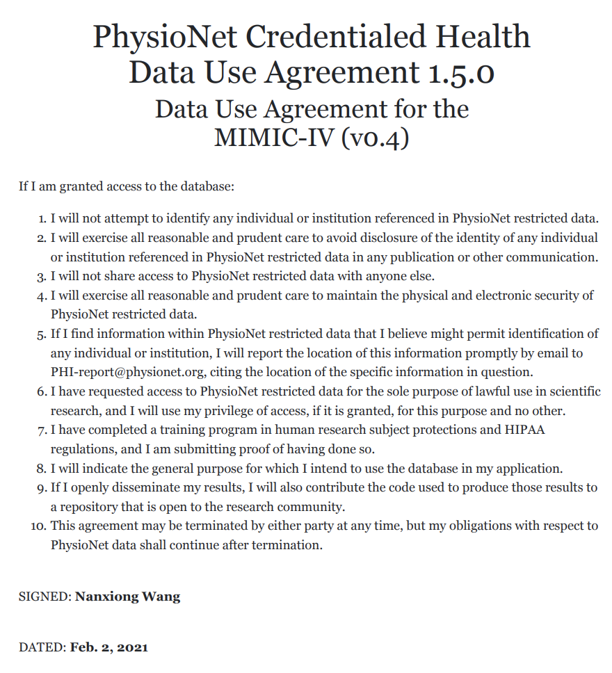

## Q2. `read.csv` (base R) vs `read_csv` (tidyverse) vs `fread` (data.table)

There are quite a few utilities in R for reading data files. Let us test the speed of reading a moderate sized compressed csv file, `admissions.csv.gz`, by three programs: `read.csv` in base R, `read_csv` in tidyverse, and `fread` in the popular data.table package. Is there any speed difference?

In this homework, we stick to the tidyverse.

```r
#read.csv
start_time <- Sys.time()
test <-read.csv(file = str_c(mimic_path, 'admissions.csv.gz'))
end_time <- Sys.time()

end_time - start_time
```

```
## Time difference of 10.26896 secs
```

```r
#read_csv
start_time <- Sys.time()
test <- read_csv(file = str_c(mimic_path, 'admissions.csv.gz'))
end_time <- Sys.time()

end_time - start_time
```

```
## Time difference of 4.453677 secs
```

```r
#fread
start_time <- Sys.time()
test <- fread(file = str_c(mimic_path, 'admissions.csv.gz'))
end_time <- Sys.time()

end_time - start_time
```

```
## Time difference of 2.03607 secs
```

## Q3. ICU stays

`icustays.csv.gz` (https://mimic-iv.mit.edu/docs/datasets/icu/icustays/) contains data about Intensive Care Units (ICU) stays. Summarize following variables using appropriate numerics or graphs:

```r
icu <- read_csv(file = str_c(mimic_path, 'icustays.csv.gz'))
```

- how many unique `stay_id`?

```r
nrow(distinct(icu,stay_id))
```

```
## [1] 69619
```

- how many unique `subject_id`?

```r
nrow(distinct(icu,subject_id))
```

```
## [1] 50048
```

- length of ICU stay

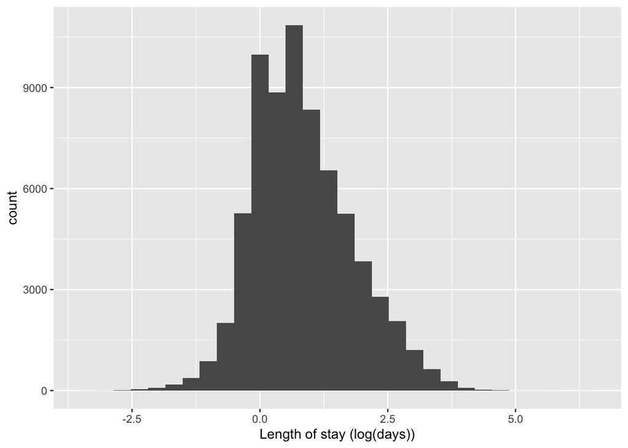

```r
icu %>%
    ggplot() +
    geom_histogram(mapping = aes(x = log(los))) +
  labs(x = "Length of stay (log(days))")
```

- first ICU unit

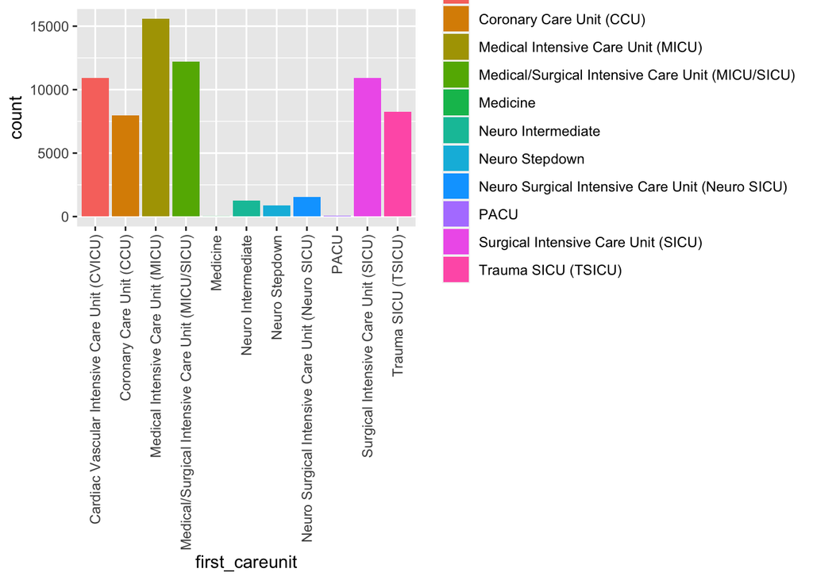

```r
icu %>%
  select(first_careunit) %>%
  ggplot(aes(x = first_careunit)) +
  geom_bar(mapping = aes(fill = first_careunit)) +
  theme(axis.text.x = element_text(angle = 90, vjust = 0.5, hjust = 1))
```

- last ICU unit

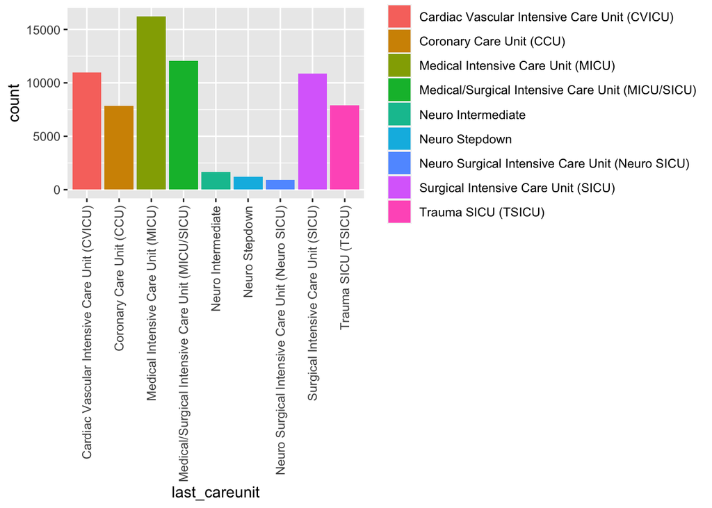

```r
icu %>%
  select(last_careunit) %>%
  ggplot(aes(x = last_careunit)) +
  geom_bar(mapping = aes(fill = last_careunit)) +
  theme(axis.text.x = element_text(angle = 90, vjust = 0.5, hjust = 1))
```

## Q4. `admission` data

Information of the patients admitted into hospital is available in `admissions.csv.gz`. See https://mimic-iv.mit.edu/docs/datasets/core/admissions/ for details of each field in this file. Summarize following variables using appropriate graphs. Explain any patterns you observe.

```r
adm <- read_csv(file = str_c(mimic_path, 'admissions.csv.gz'))
```

- admission year

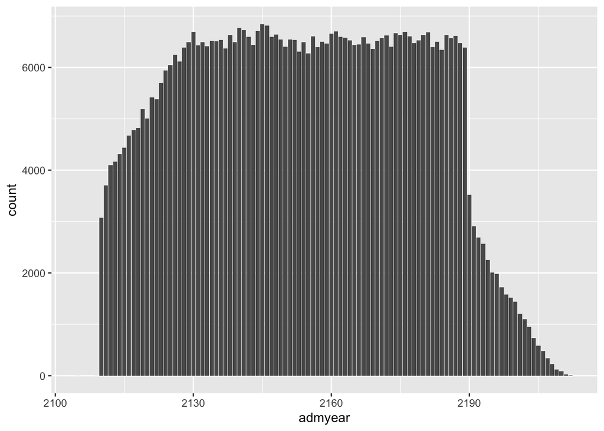

```r
adm$admyear <- as.numeric(substr(adm$admittime, 1, 4))
ggplot(data = adm) +
      geom_bar(mapping = aes(x = admyear))
```

- admission month

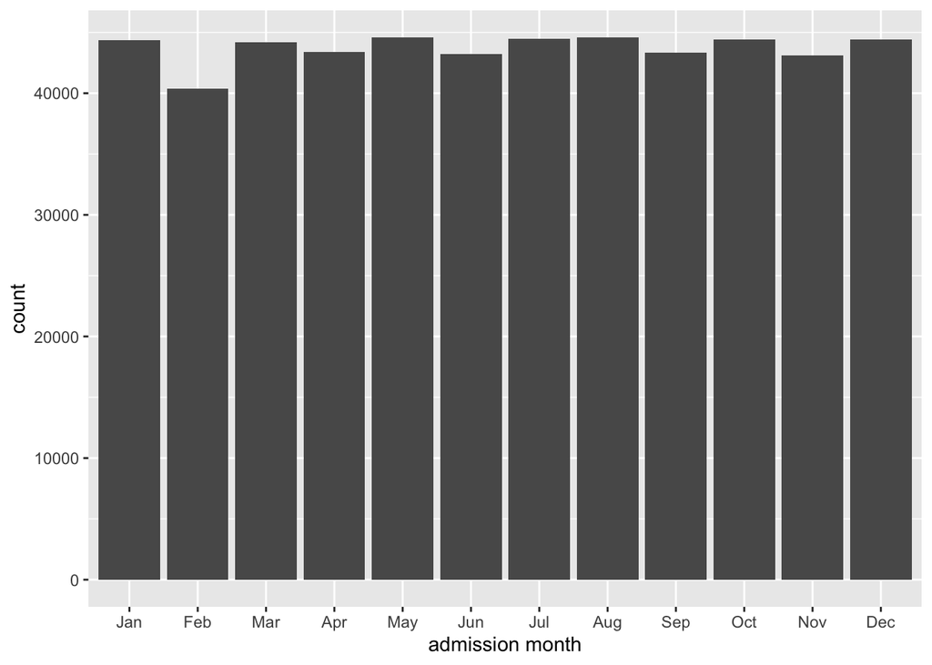

```r
adm$admmonth <- as.numeric(substr(adm$admittime, 6, 7))
ggplot(data = adm) +
    geom_bar(mapping = aes(x = admmonth, fill = admmonth)) +
    scale_x_discrete(name ="admission month",
                     limits=month.abb)
```

- admission month day

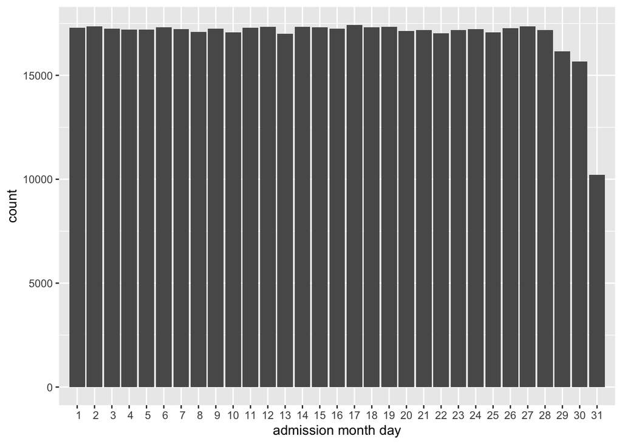

```r
adm$admday <- as.numeric(substr(adm$admittime, 9, 10))
ggplot(data = adm) +
    geom_bar(mapping = aes(x = admday, fill = admday)) +
    scale_x_discrete(name ="admission month day",
                     limits=seq(1,31,by=1))
```

- admission week day

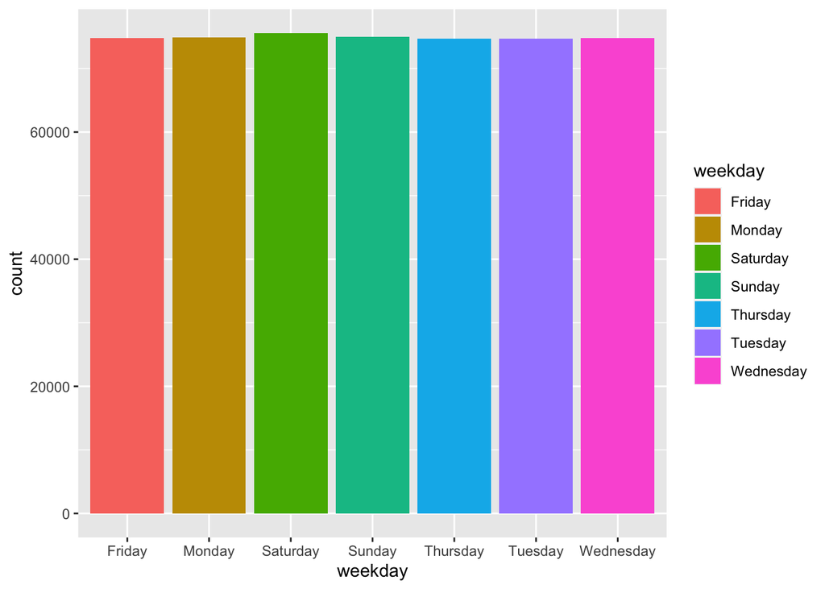

```r
adm$weekday <- weekdays(adm$admittime)
ggplot(data = adm) +
    geom_bar(mapping = aes(x = weekday, fill = weekday))
```

- admission hour (anything unusual?)  
From the graph we can see that the most people were admitted in the evening and the least was adimitted in the early morning.

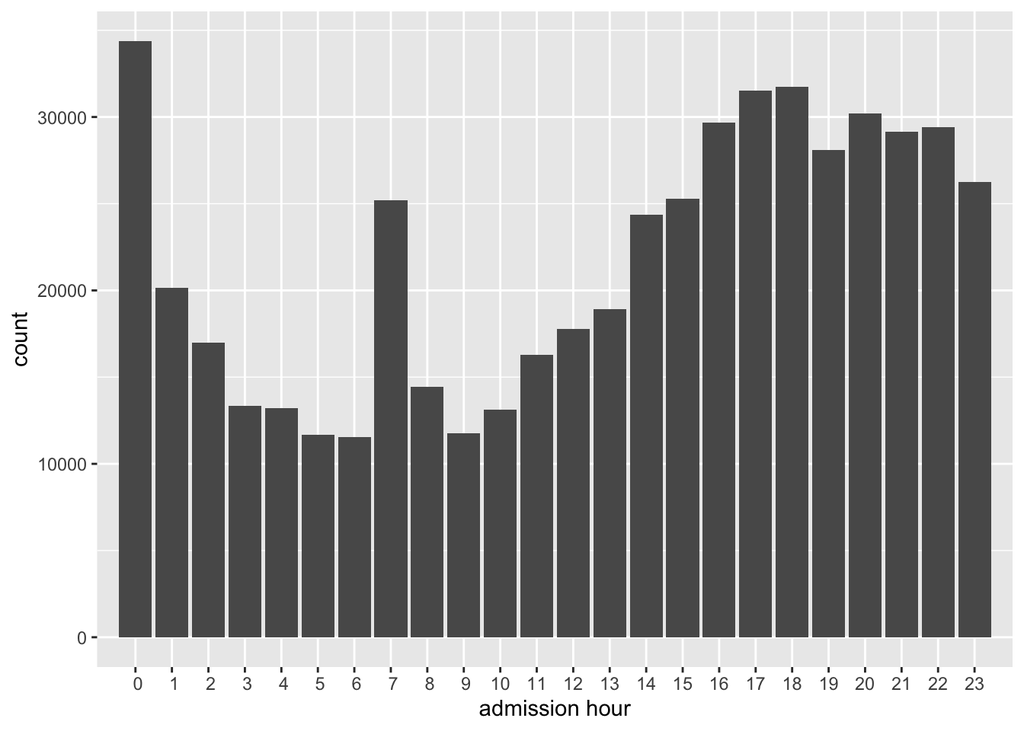

```r
adm$admhour <- as.numeric(substr(adm$admittime, 12, 13))
ggplot(data = adm) +
    geom_bar(mapping = aes(x = admhour, fill = admhour)) +
    scale_x_discrete(name ="admission hour",
                     limits=seq(0,23,by=1))
```

- number of deaths in each year

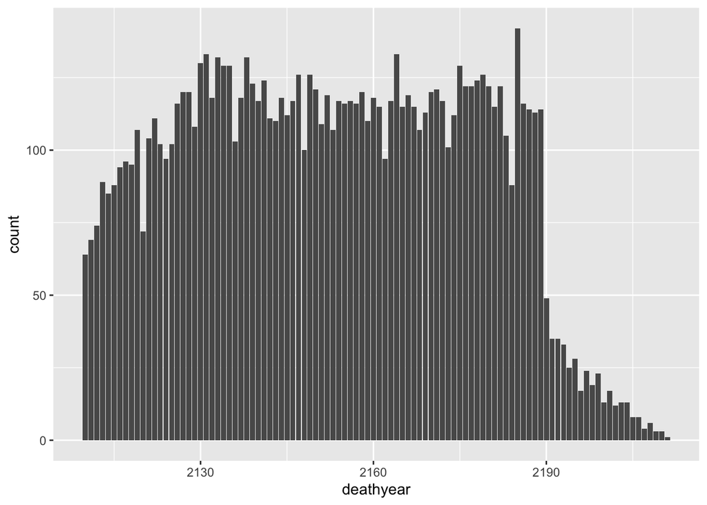

```r
adm$deathyear <- as.numeric(substr(adm$deathtime, 1, 4))
ggplot(data = adm) +
      geom_bar(mapping = aes(x = deathyear))
```

- admission type

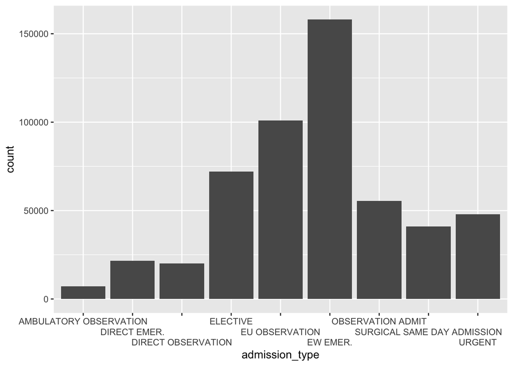

```r
ggplot(data = adm) +
      geom_bar(mapping = aes(x = admission_type)) +
      scale_x_discrete(guide = guide_axis(n.dodge=3))
```

- number of admissions per patient

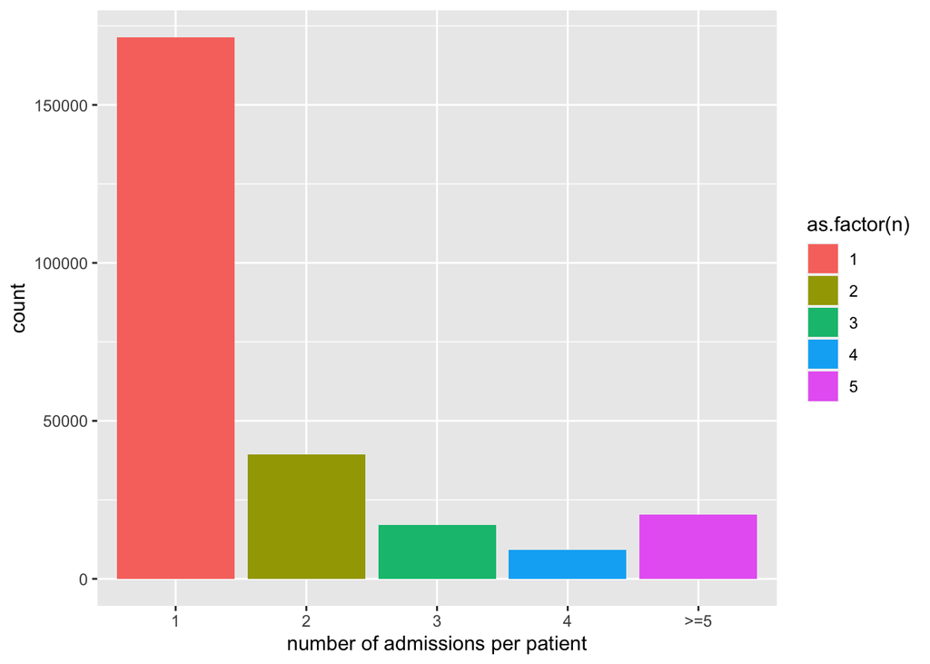

```r
adm_rep <- adm %>%
  count(subject_id) %>%
  mutate(n = (ifelse(n > 5, 5, n)))
ggplot(adm_rep) +
      geom_bar(mapping = aes(x = n, fill = as.factor(n))) +
      scale_x_discrete(name = "number of admissions per patient",
                       limits = c("1", "2", "3", "4", ">=5"))
```

- admission location

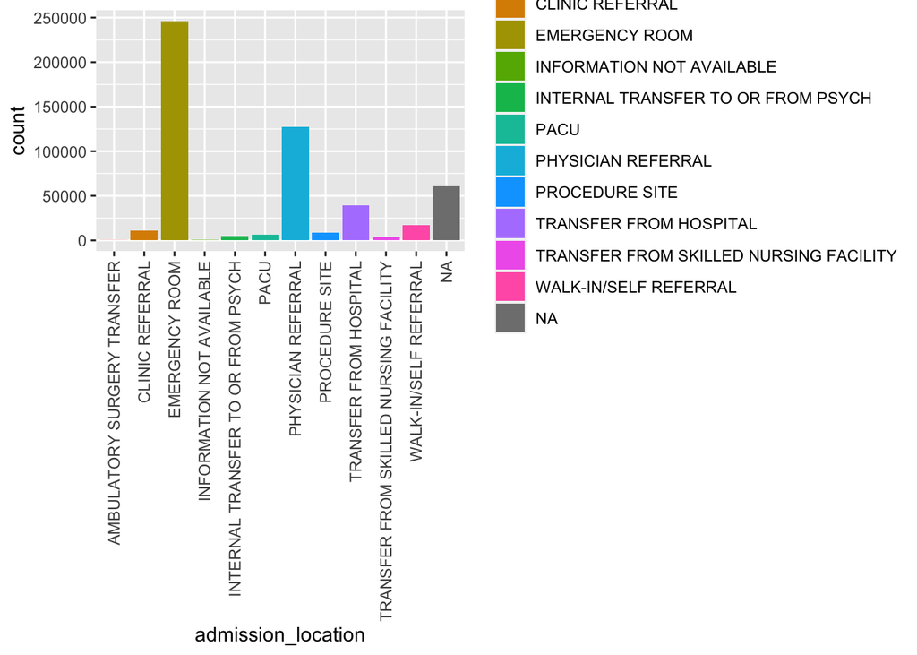

```r
ggplot(adm) +
      geom_bar(aes(x = admission_location, fill = admission_location)) +
      theme(axis.text.x = element_text(angle = 90, vjust = 0.5, hjust = 1))
```

- discharge location

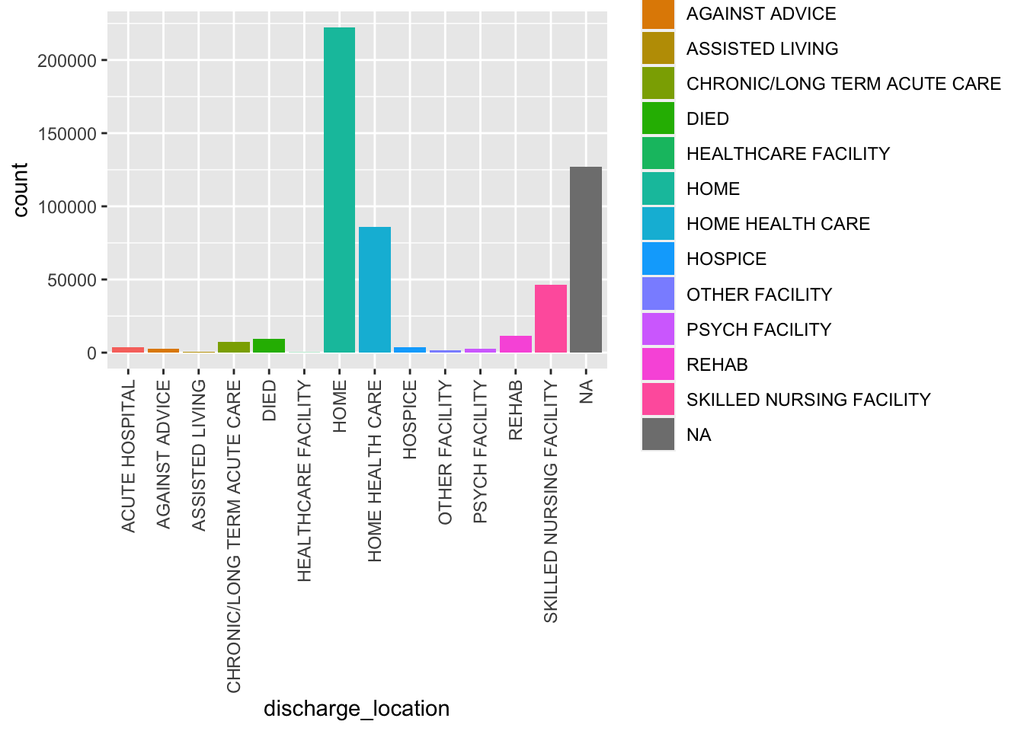

```r
ggplot(adm) +
      geom_bar(aes(x = discharge_location, fill = discharge_location)) +
      theme(axis.text.x = element_text(angle = 90, vjust = 0.5, hjust = 1))
```

- insurance

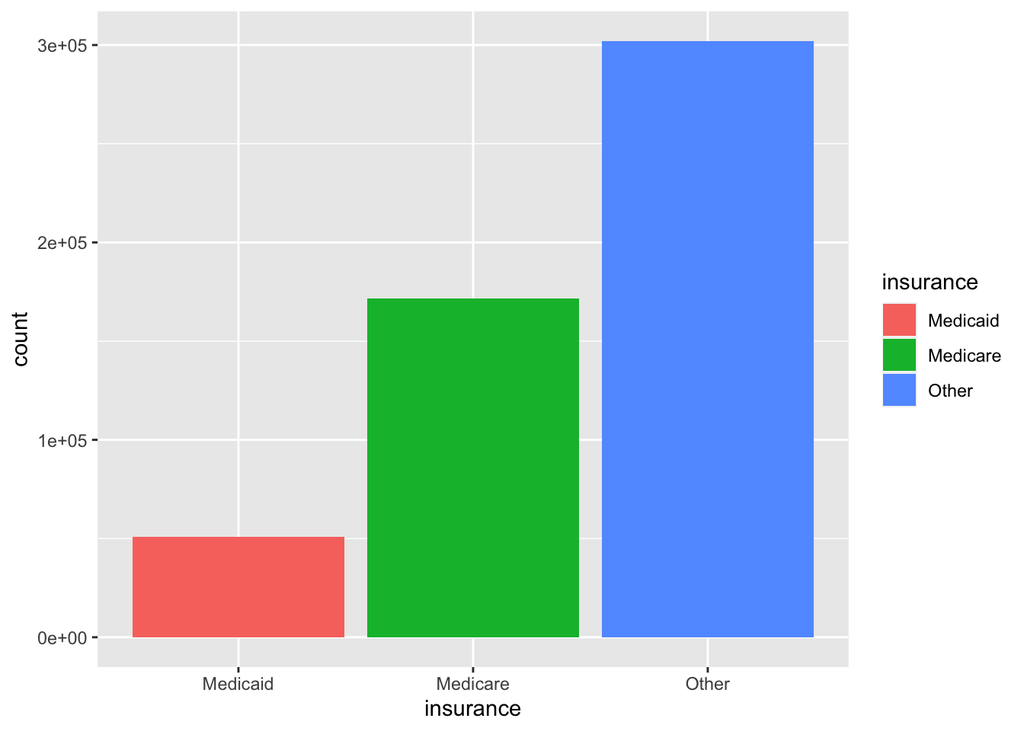

```r
ggplot(adm) +
      geom_bar(aes(x = insurance, fill = insurance))
```

- language

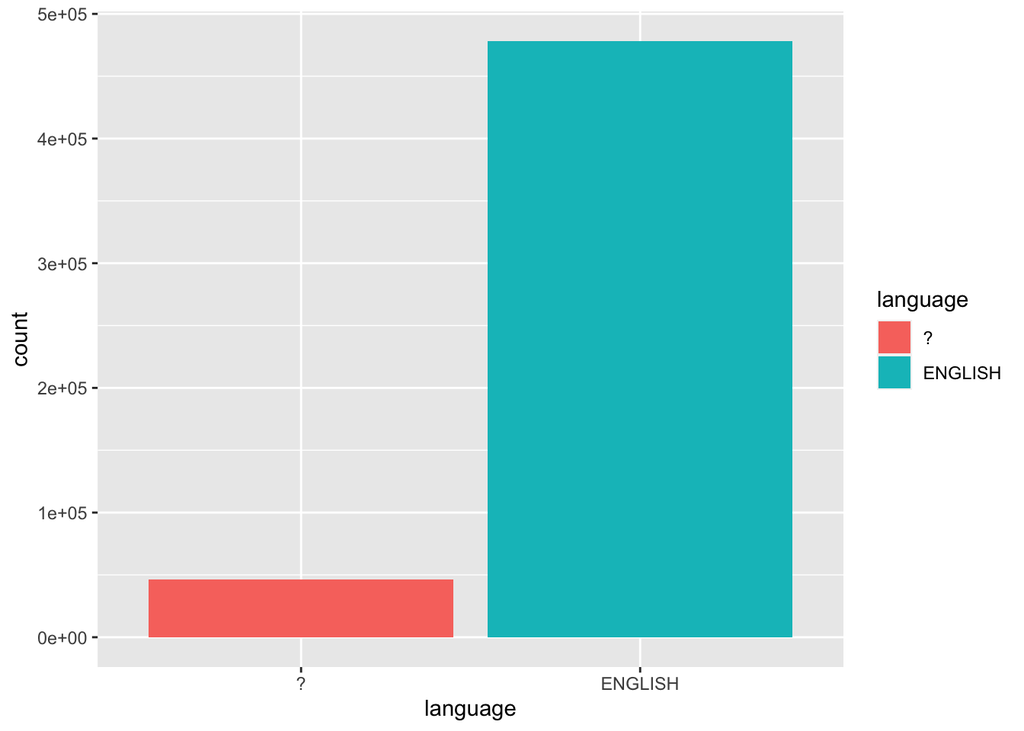

```r
ggplot(adm) +
      geom_bar(aes(x = language, fill = language))
```

- martial status

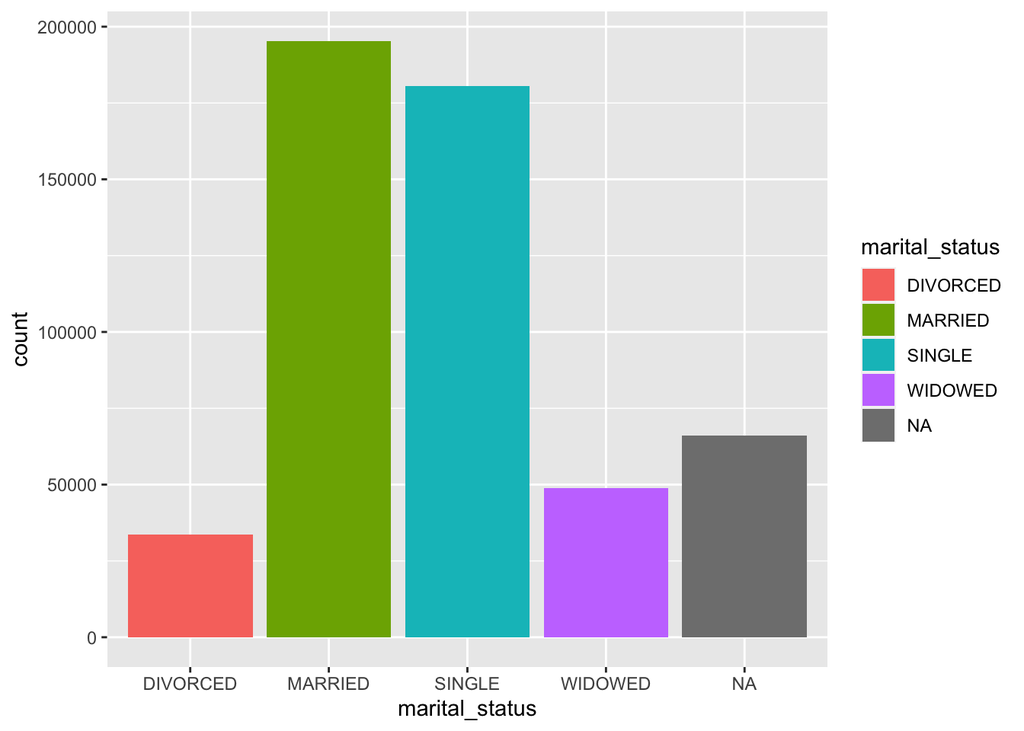

```r
ggplot(adm) +
      geom_bar(aes(x = marital_status, fill = marital_status))
```

- ethnicity

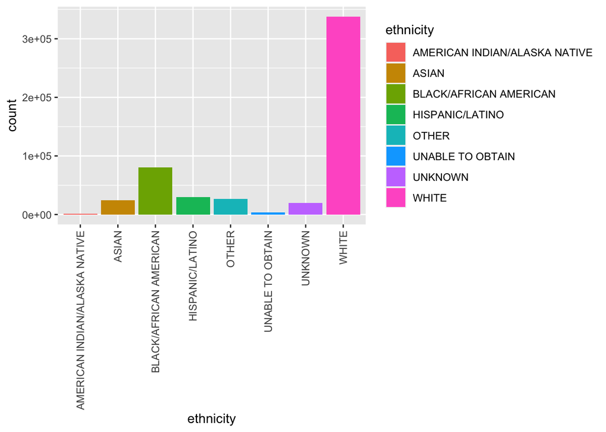

```r
ggplot(adm) +
      geom_bar(aes(x = ethnicity, fill = ethnicity)) +
      theme(axis.text.x = element_text(angle = 90, vjust = 0.5, hjust = 1))
```

- death

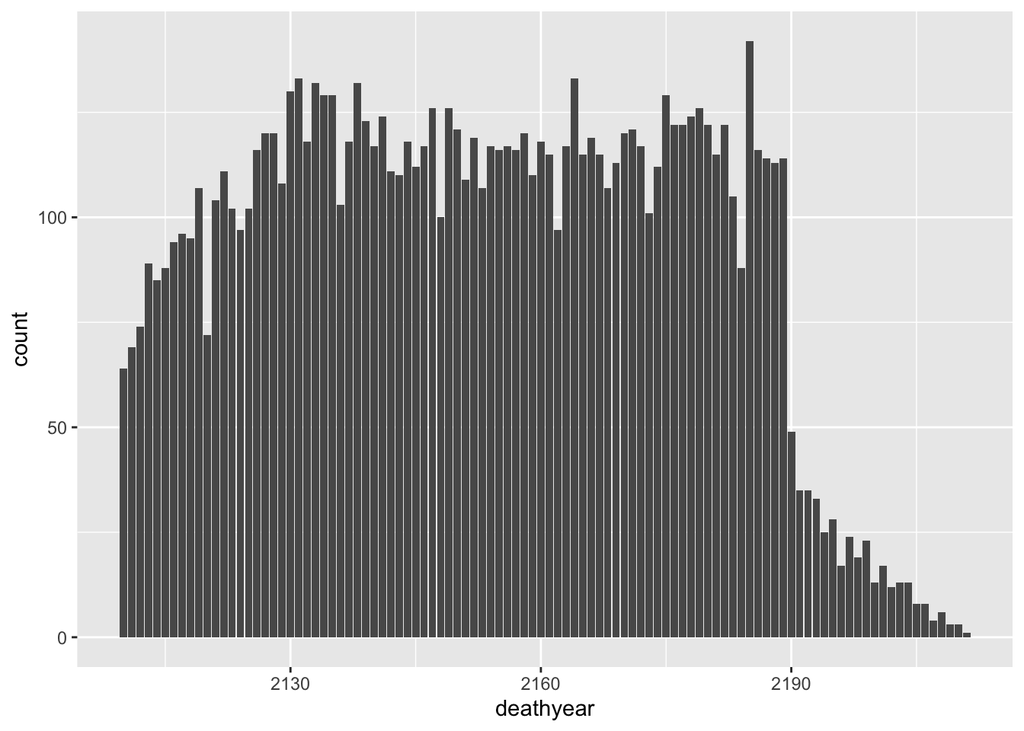

```r
ggplot(adm) +
      geom_bar(aes(x = deathyear, fill = deathyear))
```

Note it is possible that one patient (uniquely identified by the `subject_id`) is admitted into hospital multiple times. When summarizing some demographic information, it makes sense to summarize based on unique patients.

## Q5. `patient` data

Explore `patients.csv.gz` (https://mimic-iv.mit.edu/docs/datasets/core/patients/) and summarize following variables using appropriate numerics and graphs:

- `gender`
- `anchor_age` (explain pattern you see)

```r
patient <- read_csv(file = str_c(mimic_path, 'patients.csv.gz'))
```

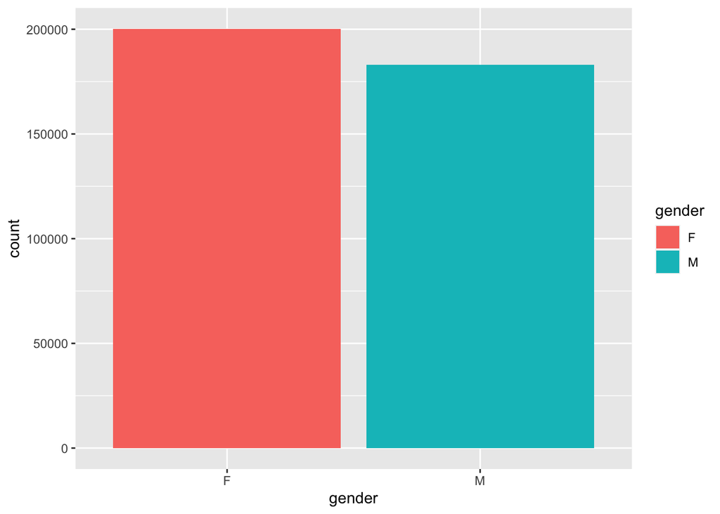

```r
patient %>%
  select(gender) %>%
  ggplot(aes(x = gender)) +
  geom_bar(mapping = aes(fill = gender))
```

```r
table(patient$anchor_age)
```

```
##
##     0    18    19    20    21    22    23    24    25    26    27    28    29
## 60879  4168  6985  9852  8575  8075  7632  6993  6398  6016  5828  5631  5337
##    30    31    32    33    34    35    36    37    38    39    40    41    42
##  5285  4990  4917  4690  4471  4380  4115  4065  4007  3912  3944  3862  3904
##    43    44    45    46    47    48    49    50    51    52    53    54    55
##  3878  3990  4195  4161  4219  4553  4552  4729  4742  5055  4866  5037  4911
##    56    57    58    59    60    61    62    63    64    65    66    67    68
##  4972  4826  4818  4945  4821  4812  4702  4646  4514  4345  4325  4206  4009
##    69    70    71    72    73    74    75    76    77    78    79    80    81
##  3927  3729  3636  3431  3291  3199  3078  3021  3006  2842  2752  2699  2694
##    82    83    84    85    86    87    88    89    91
##  2647  2414  2432  2314  2160  1941  1862  1161  7244
```

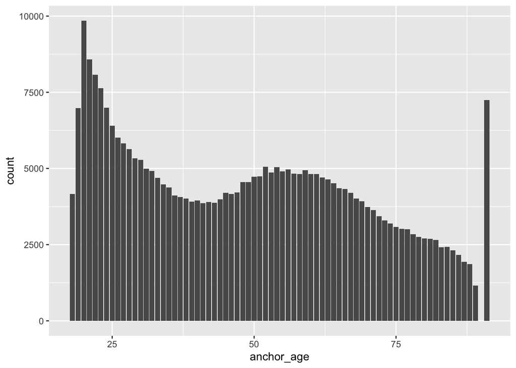

```r
#Excluded anchor_age = 0 for bettwe visualization
patient %>%
  select(anchor_age) %>%
  filter(anchor_age != 0) %>%
  ggplot(aes(x = anchor_age)) +
  geom_bar(mapping = aes(fill = anchor_age))
```

## Q6. Lab results

`labevents.csv.gz` (https://mimic-iv.mit.edu/docs/datasets/hosp/labevents/) contains all laboratory measurements for patients.

We are interested in the lab measurements of creatinine (50912), potassium (50971), sodium (50983), chloride (50902), bicarbonate (50882), hematocrit (51221), white blood cell count (51301), glucose (50931), magnesium (50960), calcium (50893), and lactate (50813). Find the `itemid`s of these lab measurements from `d_labitems.csv.gz` and retrieve a subset of `labevents.csv.gz` only containing these items.

```r
if(!file.exists("labevents_icustays.csv.gz")){
  system.time(labevents_tab <-
                fread(str_c(mimic_path, "labevents_filtered_itemid.csv.gz")) %>%
                    rename(subject_id = V1, hadm_id = V2, itemid = V3,
                           charttime = V4, valuenum = V5))
  labevents_tab %>%
    semi_join(icu, by = c("subject_id", "hadm_id")) %>%
    fwrite("labevents_icustays.csv.gz")
}

system.time(labevents_tab <- fread("labevents_icustays.csv.gz"))
```

```
##    user  system elapsed
##   3.196   1.323   6.054
```

```r
labevents_tab %>%
  as.tibble() %>%
  print(width = Inf)
```

```
## # A tibble: 8,021,352 x 5
##    subject_id  hadm_id itemid charttime           valuenum
##         <int>    <int>  <int> <chr>                  <dbl>
##  1   12457441 21673651  50882 2135-08-16 23:45:00     28
##  2   12457441 21673651  50893 2135-08-16 23:45:00      7.5
##  3   12457441 21673651  50902 2135-08-16 23:45:00     95
##  4   12457441 21673651  50912 2135-08-16 23:45:00      0.6
##  5   12457441 21673651  50960 2135-08-16 23:45:00      1.5
##  6   12457441 21673651  50971 2135-08-16 23:45:00      3
##  7   12457441 21673651  50983 2135-08-16 23:45:00    133
##  8   12457441 21673651  51221 2135-08-16 23:45:00     14.8
##  9   12457441 21673651  51301 2135-08-16 23:45:00      3.3
## 10   12457441 21673651  50813 2135-08-17 00:02:00      2
## # … with 8,021,342 more rows
```

## Q7. Vitals from chartered events

We are interested in the vitals for ICU patients: heart rate, mean and systolic blood pressure (invasive and noninvasive measurements combined), body temperature, SpO2, and respiratory rate. Find the `itemid`s of these vitals from `d_items.csv.gz` and retrieve a subset of `chartevents.csv.gz` only containing these items.

`chartevents.csv.gz` (https://mimic-iv.mit.edu/docs/datasets/icu/chartevents/) contains all the charted data available for a patient. During their ICU stay, the primary repository of a patient’s information is their electronic chart. The `itemid` variable indicates a single measurement type in the database. The `value` variable is the value measured for `itemid`.

`d_items.csv.gz` (https://mimic-iv.mit.edu/docs/datasets/icu/d_items/) is the dictionary for the `itemid` in `chartevents.csv.gz`.

```r
if(!file.exists("chartevents_icustays.csv.gz")){
  system.time(chart_tab <-
                fread(str_c(mimic_path, "chartevents_filtered_itemid.csv.gz"))
              %>%
                    rename(subject_id = V1, hadm_id = V2, stay_id = V3,
                           charttime = V4, itemid = V5, valuenum = V6))
    chart_tab %>%
    semi_join(icu, by = c("subject_id", "hadm_id")) %>%
    fwrite("chartevents_icustays.csv.gz")
}

system.time(chart_tab <- fread("chartevents_icustays.csv.gz"))
```

```
##    user  system elapsed
##  16.972   5.931  31.092
```

```r
  chart_tab %>%
  as.tibble() %>%
  print(width = Inf)
```

```
## # A tibble: 30,095,996 x 6
##    subject_id  hadm_id  stay_id charttime           itemid valuenum
##         <int>    <int>    <int> <chr>                <int>    <dbl>
##  1   10003700 28623837 35053963 2165-04-24 05:28:00 220179    152
##  2   10003700 28623837 35053963 2165-04-24 05:28:00 220181    110
##  3   10003700 28623837 35053963 2165-04-24 05:30:00 220045     65
##  4   10003700 28623837 35053963 2165-04-24 05:30:00 220210     14
##  5   10003700 28623837 35053963 2165-04-24 05:38:00 223761     97.6
##  6   10003700 28623837 35053963 2165-04-24 06:00:00 220045     56
##  7   10003700 28623837 35053963 2165-04-24 06:00:00 220179    126
##  8   10003700 28623837 35053963 2165-04-24 06:00:00 220181     88
##  9   10003700 28623837 35053963 2165-04-24 06:00:00 220210     14
## 10   10003700 28623837 35053963 2165-04-24 06:09:00 220045     55
## # … with 30,095,986 more rows
```

## Q8. Putting things together

Let us create a tibble for all ICU stays, where rows are

- first ICU stay of each unique patient
- adults (age at admission > 18)

and columns contain at least following variables

- all variables in `icustays.csv.gz`
- all variables in `admission.csv.gz`
- all variables in `patients.csv.gz`
- first lab measurements during ICU stay
- first vitals measurement during ICU stay
- an indicator variable whether the patient died within 30 days of hospital admission

```r
icu_uniq <- icu %>%
#Filter first ICU stay of each unique patient
  group_by(subject_id) %>%
  slice_min(intime) %>%
#Add in admissions
  left_join(adm, by = c("subject_id", "hadm_id")) %>%
#Add in patients
  left_join(patient, by = c("subject_id")) %>%
#Filter age > 18
  mutate(age = year(admittime) - anchor_year + anchor_age) %>%
  filter(age >= 18) %>%
  select(-age) %>%
#Add death indicator whether patient died within 30 days of admission
  mutate(d_within30 = ifelse(deathtime - intime <= 30, "Yes", "No")) %>% print()
```

```
## # A tibble: 50,048 x 33
## # Groups:   subject_id [50,048]
##    subject_id hadm_id stay_id first_careunit last_careunit intime
##         <dbl>   <dbl>   <dbl> <chr>          <chr>         <dttm>
##  1   10000032  2.91e7  3.75e7 Medical Inten… Medical Inte… 2180-07-23 14:00:00
##  2   10000980  2.69e7  3.67e7 Medical Inten… Medical Inte… 2189-06-27 08:42:00
##  3   10001217  2.46e7  3.03e7 Surgical Inte… Surgical Int… 2157-11-20 19:18:02
##  4   10001725  2.56e7  3.75e7 Medical/Surgi… Medical/Surg… 2110-04-11 15:52:22
##  5   10001884  2.62e7  3.18e7 Medical Inten… Medical Inte… 2131-01-11 04:20:05
##  6   10002013  2.36e7  3.71e7 Cardiac Vascu… Cardiac Vasc… 2160-05-18 10:00:53
##  7   10002155  2.38e7  3.46e7 Coronary Care… Coronary Car… 2129-08-04 12:45:00
##  8   10002223  2.25e7  3.99e7 Trauma SICU (… Trauma SICU … 2158-01-15 08:01:49
##  9   10002428  2.87e7  3.20e7 Medical Inten… Medical Inte… 2156-04-12 16:24:18
## 10   10002443  2.13e7  3.52e7 Coronary Care… Coronary Car… 2183-10-18 00:47:00
## # … with 50,038 more rows, and 27 more variables: outtime <dttm>, los <dbl>,
## #   admittime <dttm>, dischtime <dttm>, deathtime <dttm>, admission_type <chr>,
## #   admission_location <chr>, discharge_location <chr>, insurance <chr>,
## #   language <chr>, marital_status <chr>, ethnicity <chr>, edregtime <dttm>,
## #   edouttime <dttm>, hospital_expire_flag <dbl>, admyear <dbl>,
## #   admmonth <dbl>, admday <dbl>, weekday <chr>, admhour <dbl>,
## #   deathyear <dbl>, gender <chr>, anchor_age <dbl>, anchor_year <dbl>,
## #   anchor_year_group <chr>, dod <lgl>, d_within30 <chr>
```

```r
#Match itemid with labels from dictionary.
d_labitems <- read_csv(file = str_c(mimic_path, 'd_labitems.csv.gz'))
labitem <- labevents_tab %>%
  left_join(d_labitems, by = c("itemid")) %>%
  select(c("itemid","label")) %>% unique() %>%
  as.tibble() %>% print()
```

```
## # A tibble: 11 x 2
##    itemid label
##     <dbl> <chr>
##  1  50882 Bicarbonate
##  2  50893 Calcium, Total
##  3  50902 Chloride
##  4  50912 Creatinine
##  5  50960 Magnesium
##  6  50971 Potassium
##  7  50983 Sodium
##  8  51221 Hematocrit
##  9  51301 White Blood Cells
## 10  50813 Lactate
## 11  50931 Glucose
```

```r
d_items <- read_csv(file = str_c(mimic_path, 'd_items.csv.gz'))
```

```r
chartitem <- chart_tab %>%
  left_join(d_items, by = c("itemid")) %>%
  select(c("itemid","label")) %>% unique() %>%
  as.tibble() %>% print()
```

```
## # A tibble: 7 x 2
##   itemid label
##    <dbl> <chr>
## 1 220179 Non Invasive Blood Pressure systolic
## 2 220181 Non Invasive Blood Pressure mean
## 3 220045 Heart Rate
## 4 220210 Respiratory Rate
## 5 223761 Temperature Fahrenheit
## 6 220050 Arterial Blood Pressure systolic
## 7 220052 Arterial Blood Pressure mean
```

Now add first lab measurements during ICU stay

```r
icu_final <- labevents_tab %>%
#Keep subject_id and hadm_id of in unique table and add in intime
  semi_join(icu_uniq, by = c("subject_id", "hadm_id")) %>%
  left_join(select(icu_uniq, subject_id, hadm_id, intime),
            by = c("subject_id", "hadm_id")) %>%
  filter(charttime >= intime) %>%
  group_by(subject_id, itemid) %>%
  arrange(charttime, .by_group = TRUE) %>%
  slice_head(n = 1) %>%
  select(-charttime, -intime ) %>%
  spread(key = itemid, value = valuenum) %>%
  ungroup() %>%
  rename_at(vars(as.character(labitem$itemid)), ~labitem$label) %>% print(Inf)
```

```
## # A tibble: 48,996 x 13
##    subject_id hadm_id Lactate Bicarbonate `Calcium, Total` Chloride Creatinine
##         <dbl>   <dbl>   <dbl>       <dbl>            <dbl>    <dbl>      <dbl>
##  1   10000032  2.91e7    NA            24              9.2      102        0.4
##  2   10000980  2.69e7    NA            23              9.2      103        2.2
##  3   10001217  2.46e7    NA            23              8.2      104        0.4
##  4   10001725  2.56e7    NA            24              9.1      102        0.8
##  5   10001884  2.62e7     1.7          33              9.8       96        1.1
##  6   10002013  2.36e7    NA            23             NA        106        0.9
##  7   10002155  2.38e7    NA            28              8.8      106        1.2
##  8   10002223  2.25e7    NA            26              8.7      102        0.8
##  9   10002428  2.87e7     1.5          18              7.8       98        0.9
## 10   10002443  2.13e7     1.7          20              7.6      101        0.8
## # … with 48,986 more rows, and 6 more variables: Glucose <dbl>,
## #   Magnesium <dbl>, Potassium <dbl>, Sodium <dbl>, Hematocrit <dbl>, `White
## #   Blood Cells` <dbl>
```

Then add vital measurements during ICU stay

```r
icu_final_2 <- chart_tab %>%
#Keep subject_id and hadm_id of in unique table and add in intime
  semi_join(icu_uniq, by = c("subject_id", "hadm_id")) %>%
  left_join(select(icu_uniq, subject_id, hadm_id, intime),
            by = c("subject_id", "hadm_id")) %>%
  filter(charttime >= intime) %>%
  group_by(subject_id, itemid) %>%
  arrange(charttime, .by_group = TRUE) %>%
  slice_head(n = 1) %>%
  select(-charttime, -intime ) %>%
  spread(key = itemid, value = valuenum) %>%
  ungroup() %>%
  rename_at(vars(as.character(chartitem$itemid)), ~chartitem$label) %>%
  print(Inf)
```

```
## # A tibble: 49,868 x 10
##    subject_id hadm_id stay_id `Heart Rate` `Arterial Blood… `Arterial Blood…
##         <dbl>   <dbl>   <int>        <dbl>            <dbl>            <dbl>
##  1   10001217  2.46e7  3.03e7           98               NA               NA
##  2   10001725  2.56e7  3.75e7           85               NA               NA
##  3   10001884  2.62e7  3.18e7           38               NA               NA
##  4   10002013  2.36e7  3.71e7           99               90               65
##  5   10002155  2.38e7  3.46e7           73               NA               NA
##  6   10002223  2.25e7  3.99e7           62               NA               NA
##  7   10002428  2.87e7  3.20e7          117               NA               NA
##  8   10002428  2.87e7  3.92e7           NA              102               69
##  9   10002443  2.13e7  3.52e7          106               NA               NA
## 10   10002495  2.50e7  3.25e7           83               73               57
## # … with 49,858 more rows, and 4 more variables: `Non Invasive Blood Pressure
## #   systolic` <dbl>, `Non Invasive Blood Pressure mean` <dbl>, `Respiratory
## #   Rate` <dbl>, `Temperature Fahrenheit` <dbl>
```

Join two tables and we are done!

```r
icu_f <- icu_uniq %>%
  left_join(icu_final, by = c("subject_id", "hadm_id")) %>%
  left_join(icu_final_2, by = c("subject_id", "hadm_id")) %>%
  group_by(subject_id) %>%
  arrange(intime, .by_group = TRUE) %>%
  slice_head(n = 1) %>%
  ungroup() %>% as.tibble() %>%
  print(Inf)
```

```
## # A tibble: 50,048 x 52
##    subject_id hadm_id stay_id.x first_careunit last_careunit intime
##         <dbl>   <dbl>     <dbl> <chr>          <chr>         <dttm>
##  1   10000032  2.91e7  37529680 Medical Inten… Medical Inte… 2180-07-23 14:00:00
##  2   10000980  2.69e7  36742749 Medical Inten… Medical Inte… 2189-06-27 08:42:00
##  3   10001217  2.46e7  30327812 Surgical Inte… Surgical Int… 2157-11-20 19:18:02
##  4   10001725  2.56e7  37542711 Medical/Surgi… Medical/Surg… 2110-04-11 15:52:22
##  5   10001884  2.62e7  31832304 Medical Inten… Medical Inte… 2131-01-11 04:20:05
##  6   10002013  2.36e7  37106138 Cardiac Vascu… Cardiac Vasc… 2160-05-18 10:00:53
##  7   10002155  2.38e7  34599502 Coronary Care… Coronary Car… 2129-08-04 12:45:00
##  8   10002223  2.25e7  39908879 Trauma SICU (… Trauma SICU … 2158-01-15 08:01:49
##  9   10002428  2.87e7  31956612 Medical Inten… Medical Inte… 2156-04-12 16:24:18
## 10   10002443  2.13e7  35217462 Coronary Care… Coronary Car… 2183-10-18 00:47:00
## # … with 50,038 more rows, and 46 more variables: outtime <dttm>, los <dbl>,
## #   admittime <dttm>, dischtime <dttm>, deathtime <dttm>, admission_type <chr>,
## #   admission_location <chr>, discharge_location <chr>, insurance <chr>,
## #   language <chr>, marital_status <chr>, ethnicity <chr>, edregtime <dttm>,
## #   edouttime <dttm>, hospital_expire_flag <dbl>, admyear <dbl>,
## #   admmonth <dbl>, admday <dbl>, weekday <chr>, admhour <dbl>,
## #   deathyear <dbl>, gender <chr>, anchor_age <dbl>, anchor_year <dbl>,
## #   anchor_year_group <chr>, dod <lgl>, d_within30 <chr>, Lactate <dbl>,
## #   Bicarbonate <dbl>, `Calcium, Total` <dbl>, Chloride <dbl>,
## #   Creatinine <dbl>, Glucose <dbl>, Magnesium <dbl>, Potassium <dbl>,
## #   Sodium <dbl>, Hematocrit <dbl>, `White Blood Cells` <dbl>, stay_id.y <int>,
## #   `Heart Rate` <dbl>, `Arterial Blood Pressure systolic` <dbl>, `Arterial
## #   Blood Pressure mean` <dbl>, `Non Invasive Blood Pressure systolic` <dbl>,
## #   `Non Invasive Blood Pressure mean` <dbl>, `Respiratory Rate` <dbl>,
## #   `Temperature Fahrenheit` <dbl>
```